# PM566 Lab week 6

Author

Jordan Walton

**Read in Medical Transcriptions**

```r
library(readr)
library(dplyr)
library(tidyr)
library(ggplot2)
library(tidytext)
mt_samples <- read_csv("https://raw.githubusercontent.com/USCbiostats/data-science-data/master/00_mtsamples/mtsamples.csv")
mt_samples <- mt_samples |>
  select(description, medical_specialty, transcription)

head(mt_samples)
```

```
# A tibble: 6 × 3
  description                                    medical_specialty transcription
  <chr>                                          <chr>             <chr>
1 A 23-year-old white female presents with comp… Allergy / Immuno… "SUBJECTIVE:…
2 Consult for laparoscopic gastric bypass.       Bariatrics        "PAST MEDICA…
3 Consult for laparoscopic gastric bypass.       Bariatrics        "HISTORY OF …
4 2-D M-Mode. Doppler.                           Cardiovascular /… "2-D M-MODE:…
5 2-D Echocardiogram                             Cardiovascular /… "1.  The lef…
6 Morbid obesity.  Laparoscopic antecolic anteg… Bariatrics        "PREOPERATIV…
```

# **Question 1: What specialties do we have?**

**Answer**: there is no overlap within this. In terms of relation, we do find some similarities, with one being surgery.

```r
mt_samples %>%
  count(medical_specialty, sort = TRUE)
```

```
# A tibble: 40 × 2
   medical_specialty                 n
   <chr>                         <int>
 1 Surgery                        1103
 2 Consult - History and Phy.      516
 3 Cardiovascular / Pulmonary      372
 4 Orthopedic                      355
 5 Radiology                       273
 6 General Medicine                259
 7 Gastroenterology                230
 8 Neurology                       223
 9 SOAP / Chart / Progress Notes   166
10 Obstetrics / Gynecology         160
# ℹ 30 more rows
```

# **Question 2**

**Answer**: this makes sense, as we use “the” , “and” , and “was” a lot of our sentences as “stop words”. The first non-stop word we get is “patient”.

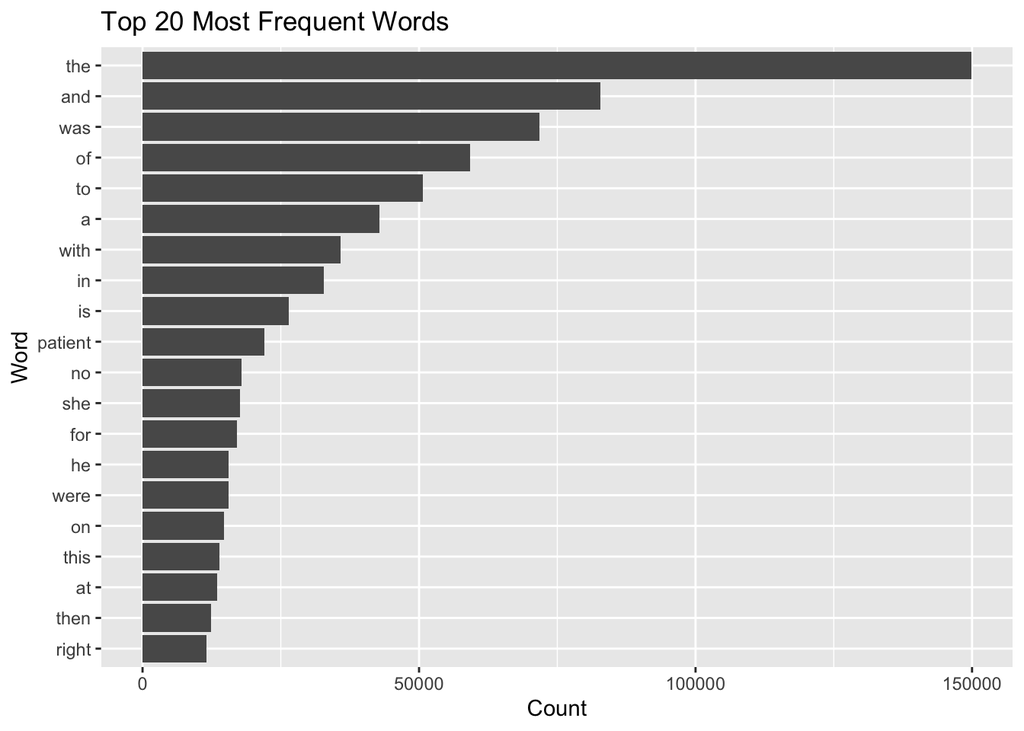

```r
library(tidytext)
mt_samples %>%
  unnest_tokens(word, transcription) %>%
  count(word, sort = TRUE) %>%
  top_n(20,n) %>%
  ggplot(aes(x = reorder(word,n), y = n)) + geom_col() + coord_flip() + labs (x = "Word", y = "Count", title = "Top 20 Most Frequent Words")
```

# **Question 3**

**Answer**: Yes, removing stop words reveals the core medical vocabulary, highlighting terms like *patient*, *procedure*, *pain*, *incision*, and *anesthesia*. This gives a much clearer picture of the dataset’s clinical focus, especially around surgical and diagnostic documentation.

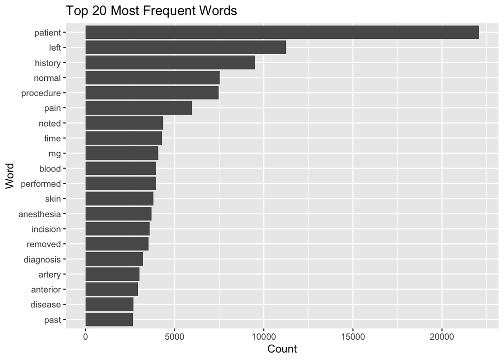

```r
mt_samples%>%
  unnest_tokens(word, transcription) %>%
  anti_join(stop_words, by = "word") %>%
  filter(!grepl("^[0-9]+$", word)) %>%
  count(word, sort = TRUE) %>%
  top_n(20,n) %>%
  ggplot(aes(x = reorder(word,n), y = n)) + geom_col() + coord_flip() + labs (x = "Word", y = "Count", title = "Top 20 Most Frequent Words")
```

# **Question 4**

**Answer**: Trigrams reveal structured, domain-specific language that single words and bigrams can’t capture, thus, giving us clearer insight into clinical documentation patterns and note types.

```r
mt_samples %>%
  unnest_tokens(bigram, transcription, token = "ngrams", n = 2) %>%
  count(bigram, sort = TRUE) %>%
  top_n(20,n)
```

```
# A tibble: 20 × 2
   bigram          n
   <chr>       <int>
 1 the patient 20307
 2 of the      19062
 3 in the      12790
 4 to the      12374
 5 was then     6956
 6 and the      6350
 7 patient was  6293
 8 the right    5509
 9 on the       5241
10 the left     4860
11 with a       4857
12 history of   4537
13 to be        4345
14 is a         4014
15 with the     4002
16 there is     3950
17 at the       3657
18 there was    3334
19 patient is   3332
20 was placed   3328
```

```r
mt_samples %>%
  unnest_tokens(trigram, transcription, token = "ngrams", n = 3) %>%
  count(trigram, sort = TRUE) %>%
  top_n(20,n)
```

```
# A tibble: 22 × 2
   trigram                n
   <chr>              <int>
 1 the patient was     6104
 2 the patient is      3075
 3 as well as          2243
 4 there is no         1678
 5 the operating room  1532
 6 patient is a        1491
 7 prepped and draped  1490
 8 was used to         1480
 9 and draped in       1372
10 at this time        1333
# ℹ 12 more rows
```

# **Question 5**

```r
mt_samples %>%
  unnest_tokens(bigram, transcription, token = "ngrams", n = 2) %>%
  separate(bigram, c("word1", "word2"), sep = " ") %>%
  filter(word1 == "patient" | word2 == "patient") %>%
  count(word1, word2, sort = TRUE)
```

```
# A tibble: 856 × 3
   word1   word2         n
   <chr>   <chr>     <int>
 1 the     patient   20307
 2 patient was        6293
 3 patient is         3332
 4 patient has        1417
 5 patient tolerated   994
 6 patient had         888
 7 patient will        616
 8 patient denies      552
 9 this    patient     470
10 patient and         377
# ℹ 846 more rows
```

# **Question 6**

```r
mt_samples %>%
  unnest_tokens(word, transcription) %>%
  anti_join(stop_words, by = "word") %>%
  filter(!grepl("^[0-9]+$", word)) %>%
  group_by(medical_specialty) %>%
  count(word, sort = TRUE) %>%
  top_n(5, n) %>%
  arrange(medical_specialty, desc(n))
```

```
# A tibble: 210 × 3
# Groups:   medical_specialty [40]
   medical_specialty    word          n
   <chr>                <chr>     <int>
 1 Allergy / Immunology history      38
 2 Allergy / Immunology noted        23
 3 Allergy / Immunology patient      22
 4 Allergy / Immunology allergies    21
 5 Allergy / Immunology nasal        13
 6 Allergy / Immunology past         13
 7 Autopsy              left         83
 8 Autopsy              inch         59
 9 Autopsy              neck         55
10 Autopsy              anterior     47
# ℹ 200 more rows
```

# **Question 7**

**Answer**: Analyzing trigrams reveals common clinical phrases like *the patient was*, *history of present*, and *tolerated the procedure*, highlighting the structured and repetitive nature of medical documentation. These patterns offer insight into note types and clinical workflows, making trigrams useful for classification and NLP tasks.

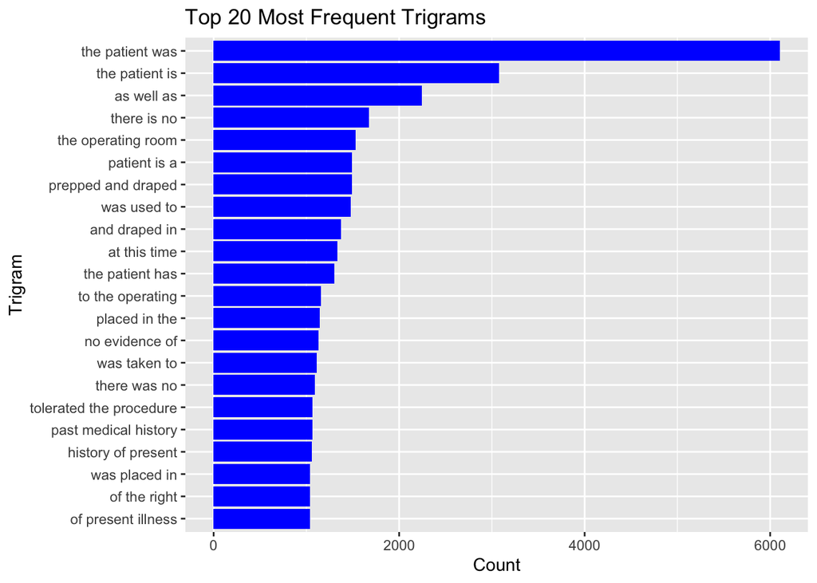

```r
library(tidytext)

# Create trigrams
trigrams <- mt_samples %>%
  unnest_ngrams(trigram, transcription, n = 3) %>%
  count(trigram, sort = TRUE) %>%
  slice_max(n, n = 20)

# Visualize
ggplot(trigrams, aes(x = reorder(trigram, n), y = n)) +
  geom_col(fill = "blue") +
  coord_flip() +
  labs(title = "Top 20 Most Frequent Trigrams", x = "Trigram", y = "Count")
```